# Columbia Extractionist task

Anna Piddubna

May 10, 2024 | 13:09:44 | CEST

### Task 0: Data frame extraction and initial manipulation

```r
df <- read.csv("C:/Users/Anna/Desktop/MCC/General work folder/Work for Charlotte/Columbia Extractivism Task/script/datos_completos_prod_regalias_2010_2021.csv")

#Looking at data frame

View(df)
unique(df$Anio)
```

```
 [1] 2010 2011 2012 2013 2014 2015 2016 2017 2018 2019
```

```r
unique(df$Municipio)
```

```
  [1] "PUERTO NARE"                "YONDO"
  [3] "PUERTO TRIUNFO"             "ARAUCA"
  [5] "ARAUQUITA"                  "SARAVENA"
  [7] "MOMPOS"                     "TAME"
  [9] "CANTAGALLO"                 "TALAIGUA NUEVO"
 [11] "CICUCO"                     "CORRALES"
 [13] "PUERTO BOYACA"              "PIAMONTE"
 [15] "SAN LUIS DE GACENO"         "TOPAGA"
 [17] "AGUAZUL"                    "YAGUARA"
 [19] "MANI"                       "TAURAMENA"
 [21] "MONTERREY"                  "NUNCHIA"
 [23] "OROCUE"                     "PAZ DE ARIPORO"
 [25] "PORE"                       "SAN LUIS DE PALENQUE"
 [27] "YOPAL"                      "TRINIDAD"
 [29] "VILLA NUEVA"                "PULI"
```

[output cut: 50 more lines]

```r
# Extracting the necessary variables and renaming

prod_df <- df %>%
  select(ITEM = ITEM,
         Municipality = Municipio,
         Year = Anio,
         Month = Mes,
         Field = Campo,
         Price_of_Hydrocarbons_USD = PrecioHidrocarburoUSD,
         Production = ProdGravableBlsKpc,
         Volume_of_Royalties = VolumenRegaliaBlsKpc,
         Royalty_COP = RegaliasCOP) %>%
  rename(Taxable_Production = Production)
```

### Task 1: PLOTTING MEAN PRICE, PRODUCTION, ROYALTIES VOLUME, AND ROYALTIES AMOUNT

**1.1. Mean Price by Year**

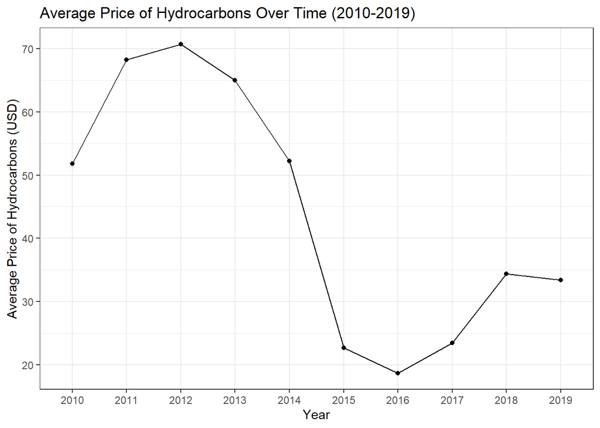

```r
# A.) Calculation

mean_price_by_year <- prod_df %>%
  group_by(Year) %>%
  summarize(mean_price_hydrocarbons = mean(Price_of_Hydrocarbons_USD, na.rm = TRUE))

df_main <- data.frame(
  Year = c(2010, 2011, 2012, 2013, 2014, 2015, 2016, 2017, 2018, 2019),
  Mean_Price = c(51.80668, 68.28489, 70.74825, 65.01000, 52.24406, 22.64876, 18.67192, 23.46762, 34.37029, 33.38670),
  Total_Production = c(679261358, 758907467, 786672230, 839173156, 839856841, 826895582, 761563641, 747341948, 783353016, 615571720),
  Total_Volume_Royalties = c(114407034, 123104916, 126081430, 129706244, 126690500, 122731659, 105555484, 95661544, 96082295, 74801617),
  Total_Amount_Royalties = c(5.41e12, 8.15e12, 8.55e12, 8.10e12, 7.43e12, 4.71e12, 3.93e12, 4.97e12, 6.52e12, 3.54e12))


# B.) Plotting Mean Price

df_main$Year <- factor(df_main$Year)

plot_mean_price <-
    ggplot(data = df_main,aes(x = Year, y = Mean_Price, group = 1)) +
    geom_point() +
    geom_line() +
    theme_bw() +
    labs(x = "Year",
         y = "Average Price of Hydrocarbons (USD)",
         title = "Average Price of Hydrocarbons Over Time (2010-2019)")

plot_mean_price
```

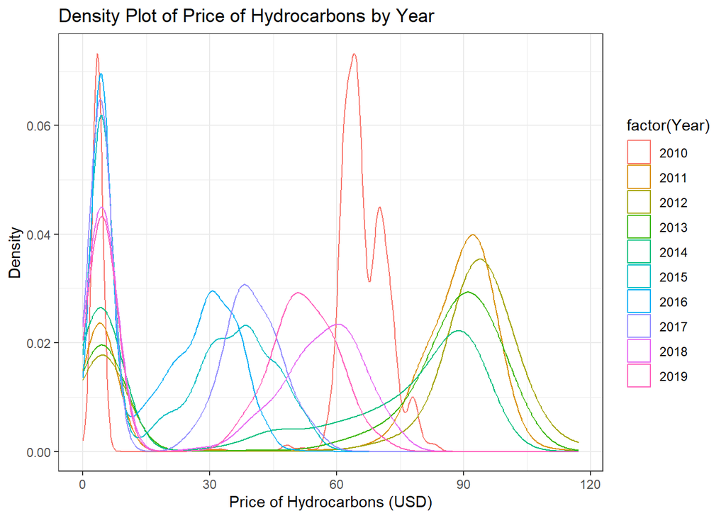

```r
# C.) Density plot for the price of hydrocarbons by year

density_plot_price <- prod_df %>%
  group_by(Year) %>%
  ggplot(aes(x = Price_of_Hydrocarbons_USD, color = factor(Year))) +
  geom_density(alpha = 0.5) +
  theme_bw() +
  labs(x = "Price of Hydrocarbons (USD)",
       y = "Density",
       title = "Density Plot of Price of Hydrocarbons by Year")

density_plot_price
```

**1.2. Total Production by Year**

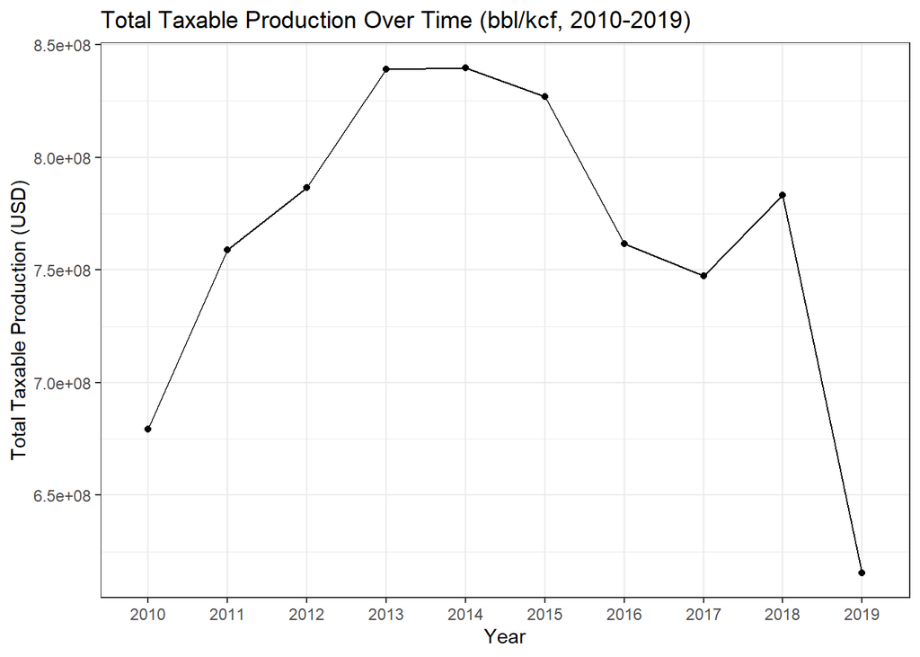

```r
# A.) Calculation

total_production_year <- prod_df %>%
  group_by(Year) %>%
  summarize(total_taxable_production = sum(Taxable_Production, na.rm = TRUE))

# B.) Plot Production by Year

df_main$Year <- factor(df_main$Year)

plot_total_production <-
  ggplot(data = df_main,aes(x = Year, y = Total_Production, group = 1)) +
  geom_point() +
  geom_line() +
  theme_bw() +
  labs(x = "Year",
       y = "Total Taxable Production (USD)",
       title = "Total Taxable Production Over Time (bbl/kcf, 2010-2019)")
plot_total_production
```

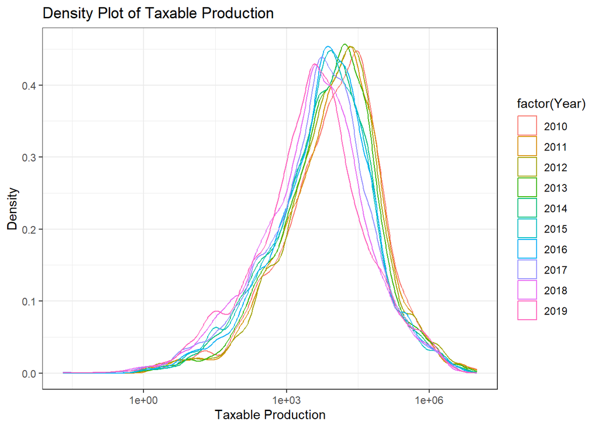

```r
# C.) Density plot of Production by Year

density_plot_production <- prod_df %>%
  group_by(Year) %>%
  ggplot(aes(x = Taxable_Production, color = factor(Year))) +
  geom_density() +
  theme_bw() +
  scale_x_log10() +
  labs(x = "Taxable Production",
       y = "Density",
       title = "Density Plot of Taxable Production")

density_plot_production
```

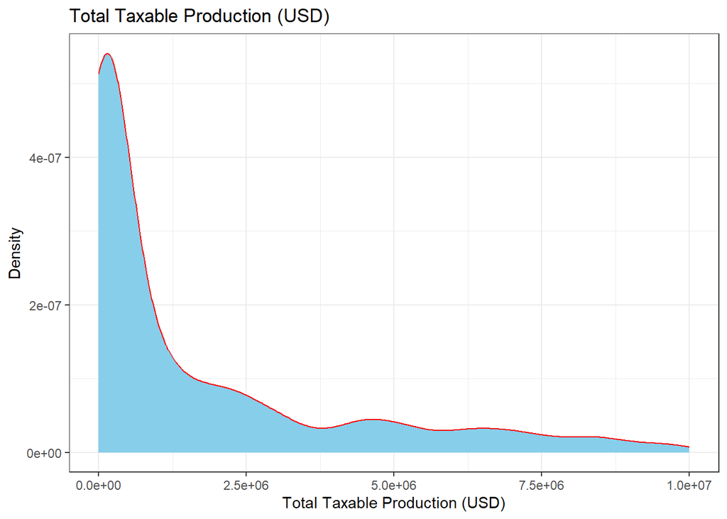

```r
# D.) Density plot of Production

df_complete <- read.csv("C:/Users/Anna/Desktop/MCC/General work folder/Work for Charlotte/Columbia Extractivism Task/script/Non-merged file.csv")

k_density_plot_total_production <- ggplot(df_complete, aes(x = Total_production_of_the_field_in_barrels_or_kilo_cubic_feet_by_municipality)) +
  geom_density(fill = "skyblue", color = "red") +
  labs(x = "Total Taxable Production (USD)",
       y = "Density",
       title = "Total Taxable Production (USD)") +
  theme_bw() +
  xlim(0, 10000000)


k_density_plot_total_production
```

```r
# E.) Summary statistics of Total Production

summary_stats <- descr(df_complete$Total_production_of_the_field_in_barrels_or_kilo_cubic_feet_by_municipality)

summary_stats
```

```
Descriptive Statistics
df_complete$Total_production_of_the_field_in_barrels_or_kilo_cubic_feet_by_municipality
N: 1240

                    Total_production_of_the_field_in_barrels_or_kilo_cubic_feet_by_municipality
----------------- -----------------------------------------------------------------------------
             Mean                                                                    7186398.40
          Std.Dev                                                                   18130429.53
              Min                                                                          0.00
               Q1                                                                      66274.96
           Median                                                                     796286.00
               Q3                                                                    5083865.89
              Max                                                                  126947888.80
              MAD                                                                    1176204.13
              IQR                                                                    4997267.96
               CV                                                                          2.52
         Skewness                                                                          3.94
      SE.Skewness                                                                          0.08
         Kurtosis                                                                         16.38
          N.Valid                                                                       1063.00
        Pct.Valid                                                                         85.73
```

```r
# F.) Summary statistics of "Continuous" Total Production (for municipalities that continuously produced between 2010 and 2019)

continuous_production <- df_complete %>%
  filter(Production_2010_2019 == 1)

summary_stats_continuous_production <- descr(continuous_production$Total_production_of_the_field_in_barrels_or_kilo_cubic_feet_by_municipality)
summary_stats_continuous_production
```

```
Descriptive Statistics
continuous_production$Total_production_of_the_field_in_barrels_or_kilo_cubic_feet_by_municipality
N: 510

                    Total_production_of_the_field_in_barrels_or_kilo_cubic_feet_by_municipality
----------------- -----------------------------------------------------------------------------
             Mean                                                                   10510817.84
          Std.Dev                                                                   22064866.64
              Min                                                                          0.00
               Q1                                                                     213455.40
           Median                                                                    1548533.00
               Q3                                                                    8303749.00
              Max                                                                  126947888.80
              MAD                                                                    2252504.54
              IQR                                                                    8077245.95
               CV                                                                          2.10
         Skewness                                                                          2.92
      SE.Skewness                                                                          0.11
         Kurtosis                                                                          8.53
          N.Valid                                                                        510.00
        Pct.Valid                                                                        100.00
```

```r
# G.) Number of distinct municipalites based on opening and closing

variation_counts <- df_complete %>%
  group_by(Opening, Closing) %>%
  summarise(municipalities = n_distinct(Municipality))

print(variation_counts)
```

```
# A tibble: 16 × 3
# Groups:   Opening [8]
   Opening Closing municipalities
     <int>   <int>          <int>
 1    2011    2014              2
 2    2011    2017              1
 3    2011    2018              3
 4    2011      NA              5
 5    2012    2017              2
 6    2012    2018              2
 7    2013    2018              1
 8    2014    2017              1
 9    2015    2018              3
10    2015      NA              2
11    2016      NA              1
12    2017    2018              2
13      NA    2014              1
14      NA    2017              4
15      NA    2018             41
16      NA      NA            124
```

**1.3. Total Volume of Royalties**

```r
# A.) Calculation
total_volume_year <- prod_df %>%
  group_by(Year) %>%
  summarize(total_volume_of_royalties = sum(Volume_of_Royalties, na.rm = TRUE))

total_volume_year
```

```
# A tibble: 10 × 2
    Year total_volume_of_royalties
   <int>                     <dbl>
 1  2010                114407034.
 2  2011                123104916.
 3  2012                126081430.
 4  2013                129706244.
 5  2014                126690500.
 6  2015                122731659.
 7  2016                105555484.
 8  2017                 95661544.
 9  2018                 96082295.
10  2019                 74801617.
```

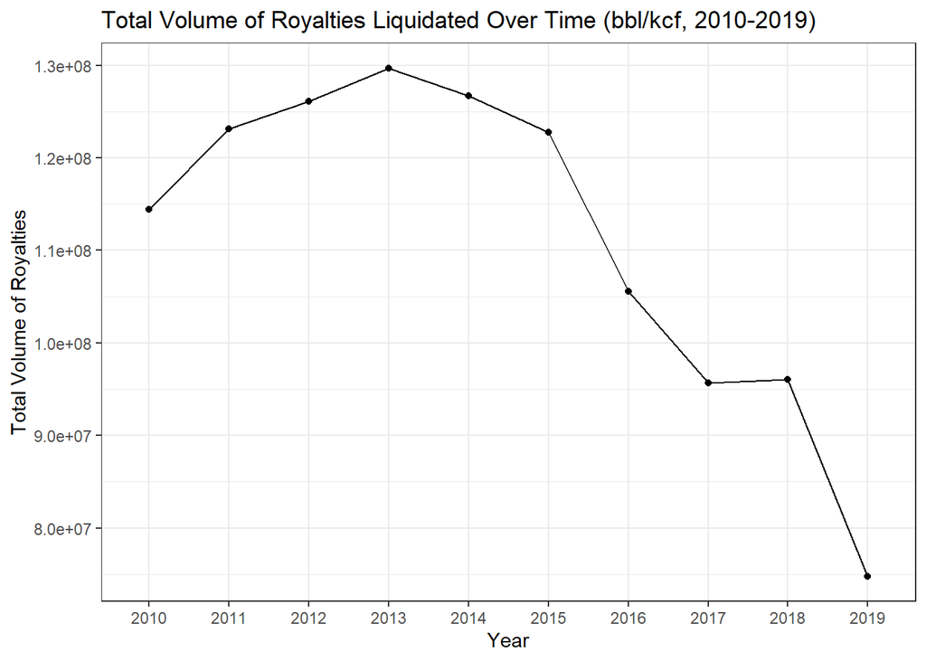

```r
# B.) Plot Total Volume of Royalties Over Time

df_main$Year <- factor(df_main$Year)

plot_total_volume_royalties <-
  ggplot(data = df_main,aes(x = Year, y = Total_Volume_Royalties, group = 1)) +
  geom_point() +
  geom_line() +
  theme_bw() +
  labs(x = "Year",
       y = "Total Volume of Royalties",
       title = "Total Volume of Royalties Liquidated Over Time (bbl/kcf, 2010-2019)")
plot_total_volume_royalties
```

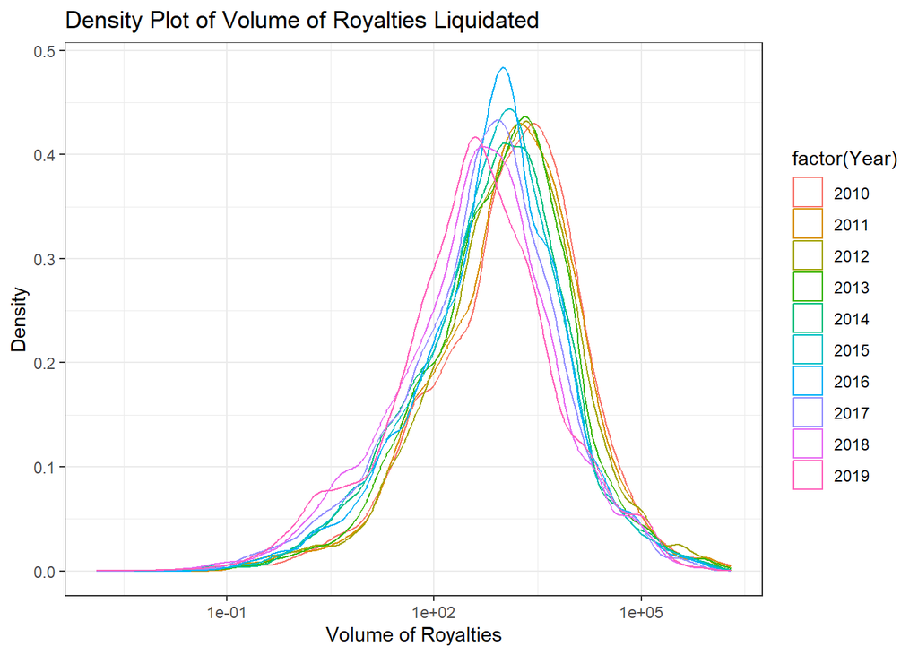

```r
# C.) Density plot volume of royalties

df_main$Year <- factor(df_main$Year)

density_plot_volume_royalties <- prod_df %>%
  group_by(Year) %>%
  ggplot(aes(x = Volume_of_Royalties, color = factor(Year))) +
  geom_density() +
  theme_bw() +
  scale_x_log10() +
  labs(x = "Volume of Royalties",
       y = "Density",
       title = "Density Plot of Volume of Royalties Liquidated")
density_plot_volume_royalties
```

**1.4. Amount of Royalties by Year**

```r
# A.) Calculation

total_amount_royalties <- prod_df %>%
  group_by(Year) %>%
  summarize(total_amount_royalties = sum(Royalty_COP, na.rm = TRUE))

total_amount_royalties
```

```
# A tibble: 10 × 2
    Year total_amount_royalties
   <int>                  <dbl>
 1  2010                5.41e12
 2  2011                8.15e12
 3  2012                8.55e12
 4  2013                8.10e12
 5  2014                7.43e12
 6  2015                4.71e12
 7  2016                3.93e12
 8  2017                4.97e12
 9  2018                6.52e12
10  2019                3.54e12
```

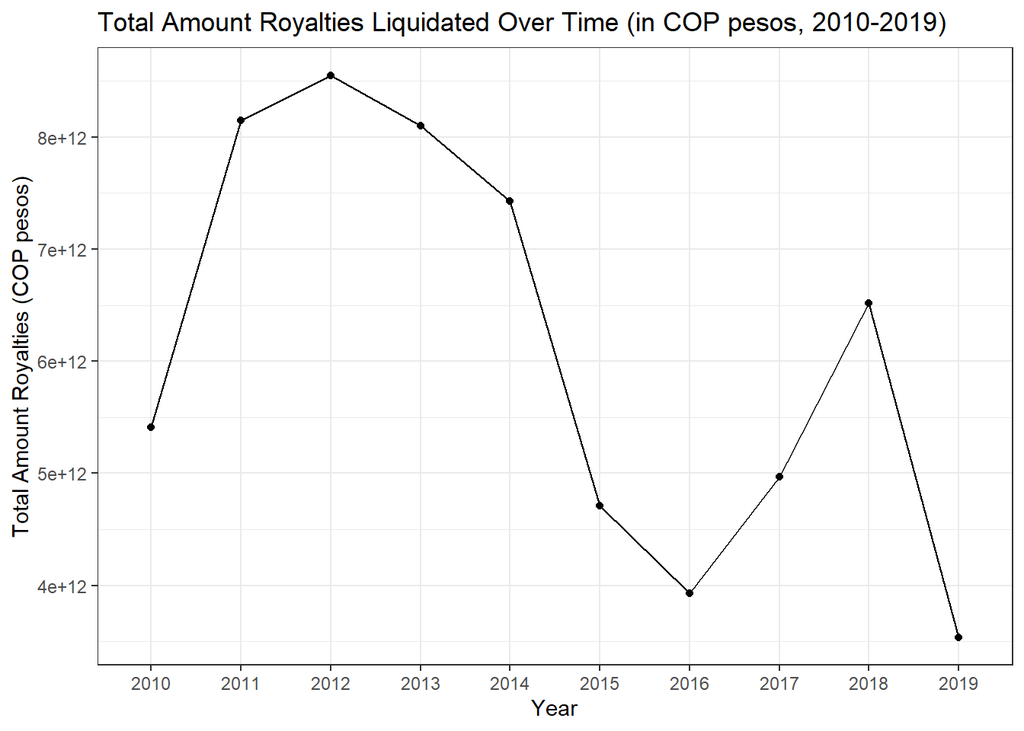

```r
# B) Plot Total Amount of Royalties by Year

df_main$Year <- factor(df_main$Year)

plot_amount_royalties <-
  ggplot(data = df_main,aes(x = Year, y = Total_Amount_Royalties, group = 1)) +
  geom_point() +
  geom_line() +
  theme_bw() +
  labs(x = "Year",
       y = "Total Amount Royalties (COP pesos)",
       title = "Total Amount Royalties Liquidated Over Time (in COP pesos, 2010-2019)")
plot_amount_royalties
```

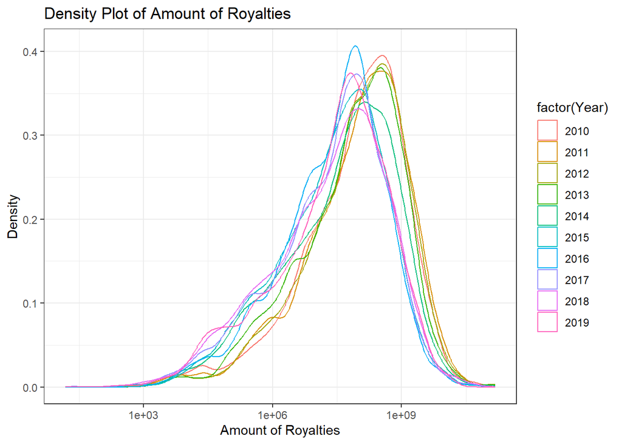

```r
# C) Density plot for amount of royalties

df_main$Year <- factor(df_main$Year)

density_plot_amount_royalties <- prod_df %>%
  filter(!is.na(Royalty_COP)) %>%
  group_by(Year) %>%
  ggplot(aes(x = Royalty_COP, color = factor(Year))) +
  geom_density() +
  theme_bw() +
  scale_x_log10() +
  labs(x = "Amount of Royalties",
       y = "Density",
       title = "Density Plot of Amount of Royalties")

density_plot_amount_royalties
```

### Task 2: HOW MANY MUNICIPALITIES ARE PRODUCING?

```r
names(prod_df)
```

```
[1] "ITEM"                      "Municipality"
[3] "Year"                      "Month"
[5] "Field"                     "Price_of_Hydrocarbons_USD"
[7] "Taxable_Production"        "Volume_of_Royalties"
[9] "Royalty_COP"
```

```r
num_municipalities <- prod_df %>%
  filter(!is.na(Taxable_Production)) %>%
  select(Municipality) %>%
  n_distinct()
print(num_municipalities)
```

```
[1] 129
```

### Task 3: FIELD BY MUNICIPALITY

```r
unique_fields_by_municipality <- prod_df %>%
  filter(!is.na(Field)) %>%
  group_by(Municipality) %>%
  summarize(unique_fields = n_distinct(Field))

print(unique_fields_by_municipality)
```

```
# A tibble: 129 × 2
   Municipality unique_fields
   <chr>                <int>
 1 ACACIAS                  8
 2 AGUACHICA                9
 3 AGUAZUL                 15
 4 AIPE                    12
 5 ALVARADO                 1
 6 ARAUCA                  10
 7 ARAUQUITA               26
 8 ARIGUANI                 2
 9 ASTREA                   1
10 BARAYA                   2
# ℹ 119 more rows
```

```r
View(unique_fields_by_municipality)

write.csv(unique_fields_by_municipality, "Unique_Fields_by_Municipality.csv", row.names = FALSE) # Save csv
```

### Tast 4: TOP 10 MUNICIPALITIES

```r
top_municipalities <- prod_df %>%
  group_by(Municipality) %>%
  summarize(total_production = sum(Taxable_Production, na.rm = TRUE)) %>%
  arrange(desc(total_production)) %>%  # Arr. descending order of production
  top_n(10)

print(top_municipalities)
```

```
# A tibble: 10 × 2
   Municipality    total_production
   <chr>                      <dbl>
 1 PUERTO GAITAN         853044779.
 2 MANAURE               846785683.
 3 AGUAZUL               769271324.
 4 YOPAL                 716585693.
 5 TAURAMENA             709557875.
 6 URIBIA                357073669.
 7 ACACIAS               350686052.
 8 RIOHACHA              333102709.
 9 CASTILLA NUEVA        228429596.
10 BARRANCABERMEJA       148494318.
```

### Task 5: PLOT PRODUCTION BY TOP 10 MUNICIPALITEIS

```r
# A.) Calculate and separate total production by year and municipality

total_production <- prod_df %>%
  group_by(Year, Municipality) %>%
  summarize(total_production = sum(Taxable_Production, na.rm = TRUE))

View(total_production)

unique(top_municipalities$Municipality)
```

```
 [1] "PUERTO GAITAN"   "MANAURE"         "AGUAZUL"         "YOPAL"
 [5] "TAURAMENA"       "URIBIA"          "ACACIAS"         "RIOHACHA"
 [9] "CASTILLA NUEVA"  "BARRANCABERMEJA"
```

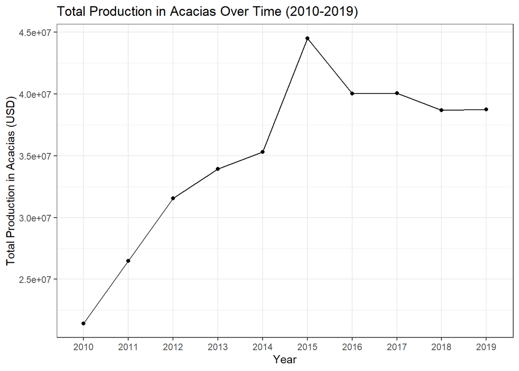

```r
# B.) PLOT FOR TOP TEN MUNICIPALITIES

#1 PLOT FOR Acacias MUNICIPALITY

total_production$Year <- factor(total_production$Year)

plot_Acacias <-  total_production %>%
  filter(Municipality == "ACACIAS") %>%
  ggplot(aes(x = Year, y = total_production, group = 1)) +
  geom_point() +
  geom_line() +
  theme_bw() +
  labs(x = "Year",
       y = "Total Production in Acacias (USD)",
       title = "Total Production in Acacias Over Time (2010-2019)")

plot_Acacias
```

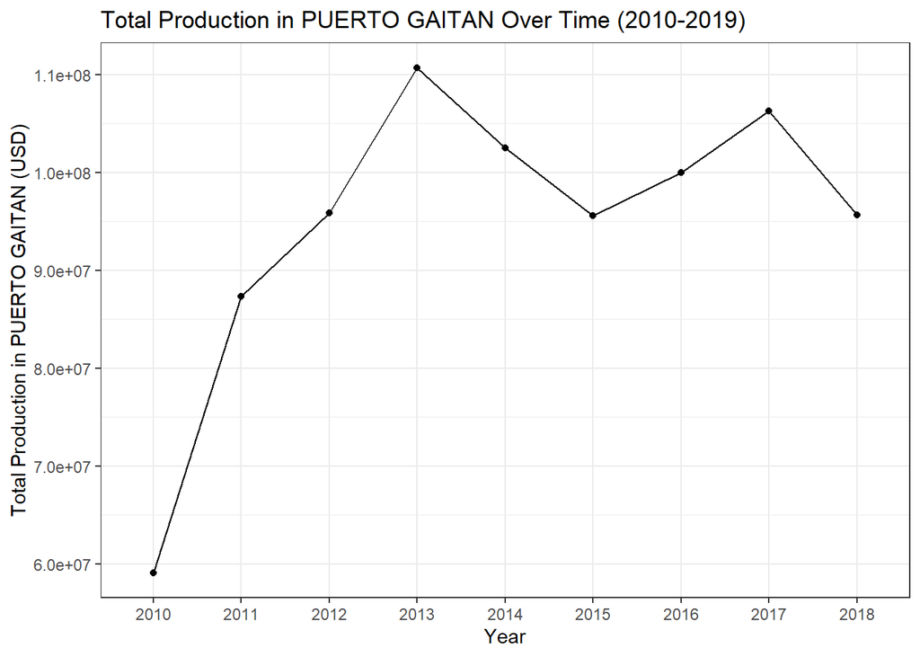

```r
#2. PLOT FOR PUERTO GAITAN MUNICIPALITY


total_production$Year <- factor(total_production$Year)

plot_PUERTO_GAITAN <-  total_production %>%
  filter(Municipality == "PUERTO GAITAN") %>%
  ggplot(aes(x = Year, y = total_production, group = 1)) +
  geom_point() +
  geom_line() +
  theme_bw() +
  labs(x = "Year",
       y = "Total Production in PUERTO GAITAN (USD)",
       title = "Total Production in PUERTO GAITAN Over Time (2010-2019)")

plot_PUERTO_GAITAN
```

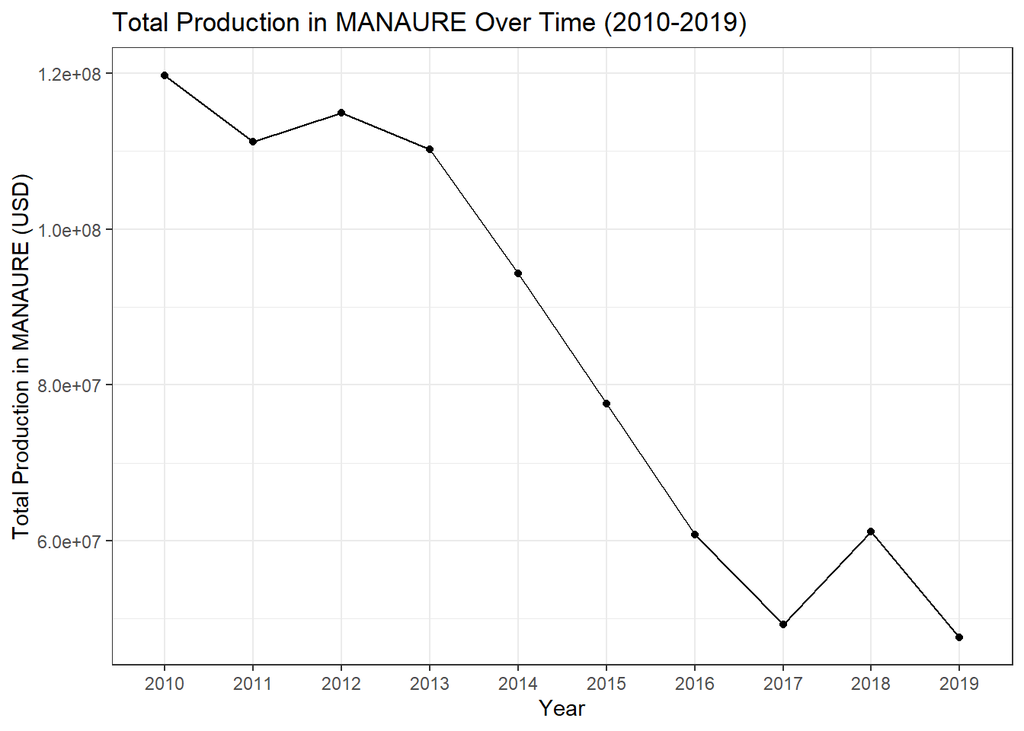

```r
# 3. PLOT FOR MANAURE MUNICIPALITY

total_production$Year <- factor(total_production$Year)

plot_MANAURE <-  total_production %>%
  filter(Municipality == "MANAURE") %>%
  ggplot(aes(x = Year, y = total_production, group = 1)) +
  geom_point() +
  geom_line() +
  theme_bw() +
  labs(x = "Year",
       y = "Total Production in MANAURE (USD)",
       title = "Total Production in MANAURE Over Time (2010-2019)")

plot_MANAURE
```

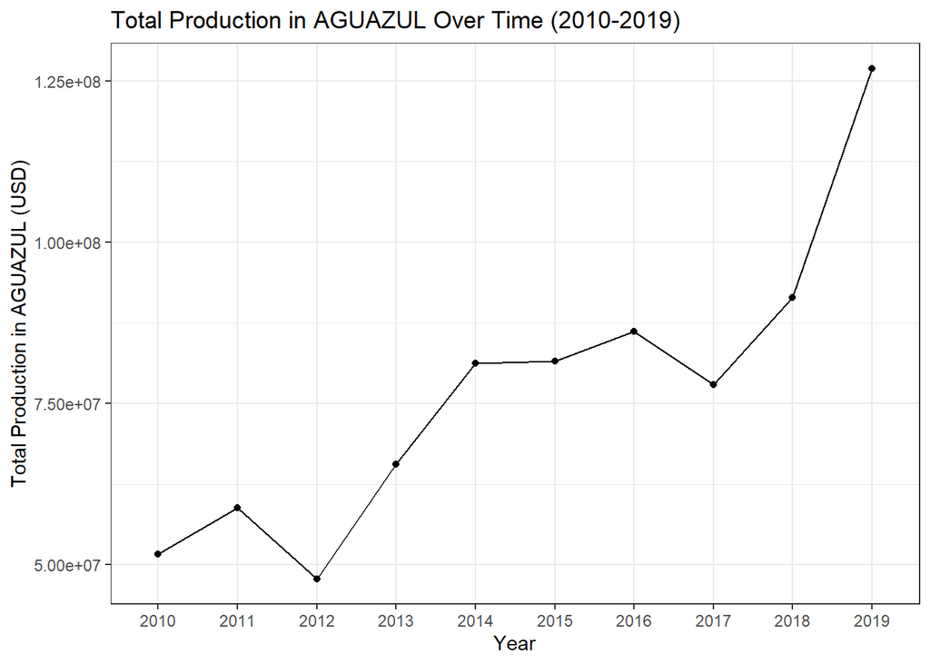

```r
# 4. PLOT FOR AGUAZUL MUNICIPALITY
total_production$Year <- factor(total_production$Year)

plot_AGUAZUL <-  total_production %>%
  filter(Municipality == "AGUAZUL") %>%
  ggplot(aes(x = Year, y = total_production, group = 1)) +
  geom_point() +
  geom_line() +
  theme_bw() +
  labs(x = "Year",
       y = "Total Production in AGUAZUL (USD)",
       title = "Total Production in AGUAZUL Over Time (2010-2019)")

plot_AGUAZUL
```

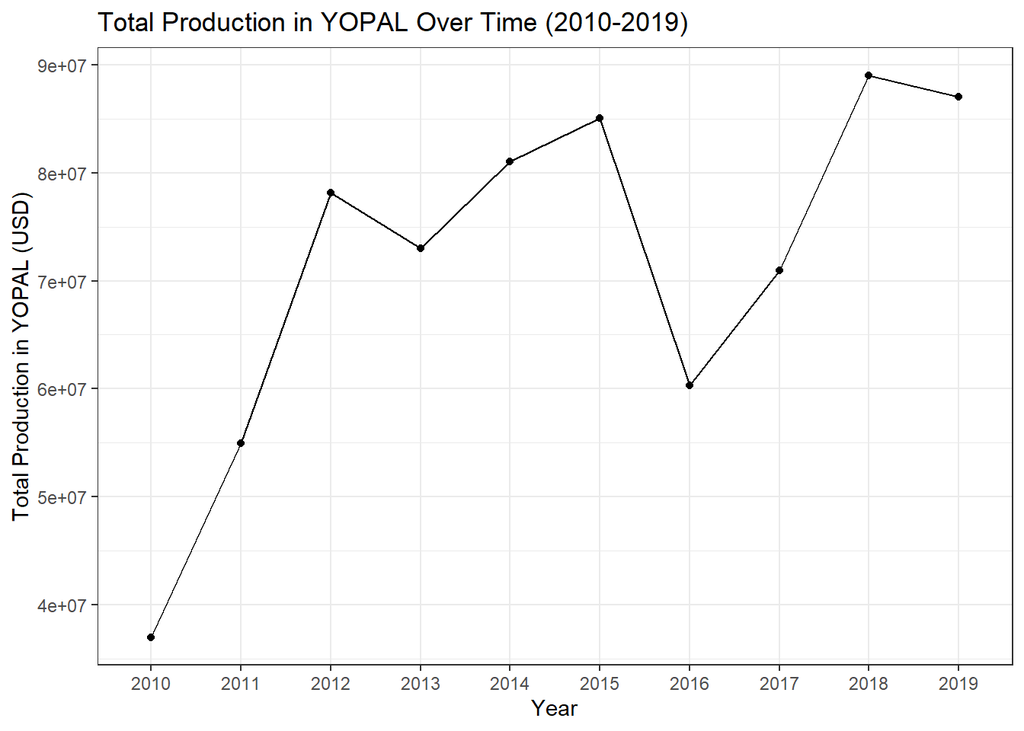

```r
# 5. PLOT FOR YOPAL MUNICIPALITY

total_production$Year <- factor(total_production$Year)

plot_YOPAL <-  total_production %>%
  filter(Municipality == "YOPAL") %>%
  ggplot(aes(x = Year, y = total_production, group = 1)) +
  geom_point() +
  geom_line() +
  theme_bw() +
  labs(x = "Year",
       y = "Total Production in YOPAL (USD)",
       title = "Total Production in YOPAL Over Time (2010-2019)")

plot_YOPAL
```

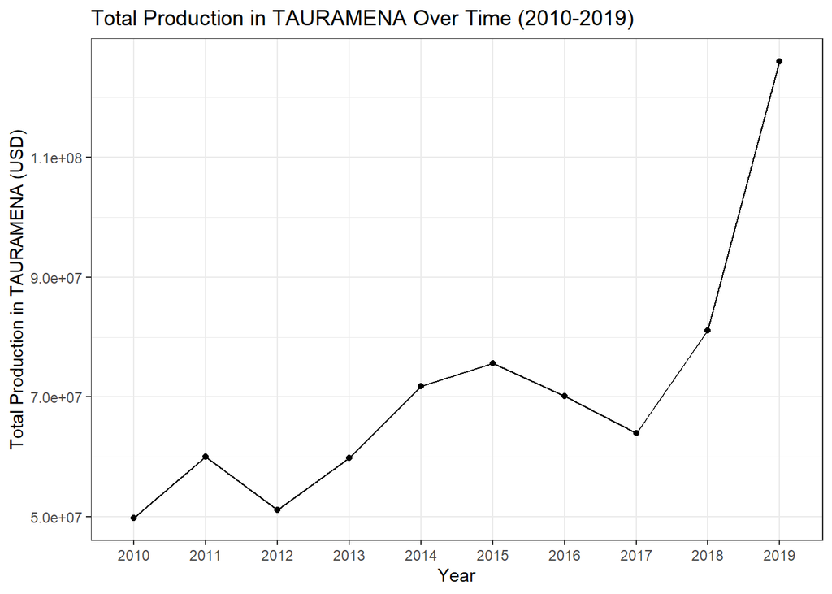

```r
# 6. PLOT FOR TAURAMENA MUNICIPALITY

total_production$Year <- factor(total_production$Year)

plot_TAURAMENA <-  total_production %>%
  filter(Municipality == "TAURAMENA") %>%
  ggplot(aes(x = Year, y = total_production, group = 1)) +
  geom_point() +
  geom_line() +
  theme_bw() +
  labs(x = "Year",
       y = "Total Production in TAURAMENA (USD)",
       title = "Total Production in TAURAMENA Over Time (2010-2019)")

plot_TAURAMENA
```

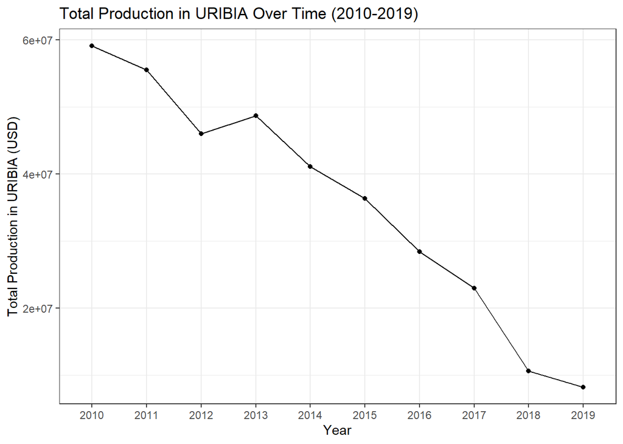

```r
# 7. PLOT FOR URIBIA MUNICIPALITY

total_production$Year <- factor(total_production$Year)

plot_URIBIA <-  total_production %>%
  filter(Municipality == "URIBIA") %>%
  ggplot(aes(x = Year, y = total_production, group = 1)) +
  geom_point() +
  geom_line() +
  theme_bw() +
  labs(x = "Year",
       y = "Total Production in URIBIA (USD)",
       title = "Total Production in URIBIA Over Time (2010-2019)")

plot_URIBIA
```

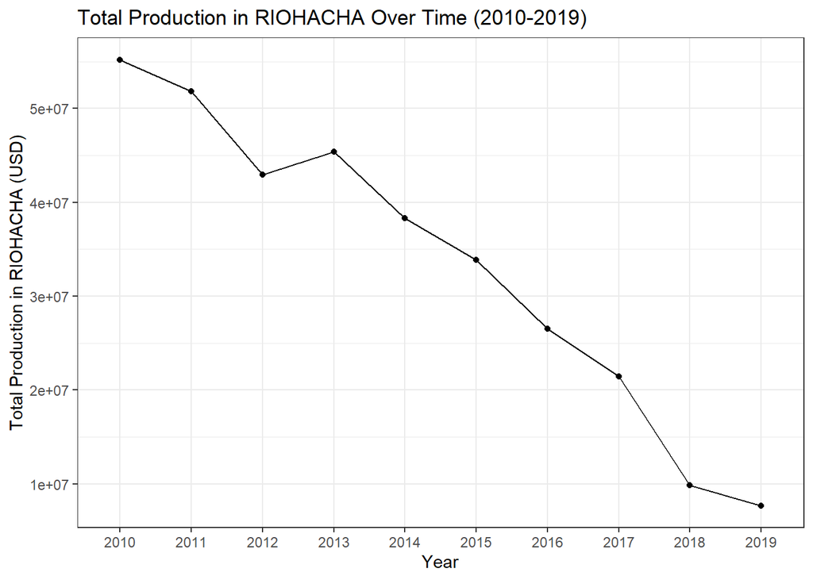

```r
# 8. PLOT FOR RIOHACHA MUNICIPALITY
total_production$Year <- factor(total_production$Year)

plot_RIOHACHA <-  total_production %>%
  filter(Municipality == "RIOHACHA") %>%
  ggplot(aes(x = Year, y = total_production, group = 1)) +
  geom_point() +
  geom_line() +
  theme_bw() +
  labs(x = "Year",
       y = "Total Production in RIOHACHA (USD)",
       title = "Total Production in RIOHACHA Over Time (2010-2019)")

plot_RIOHACHA
```

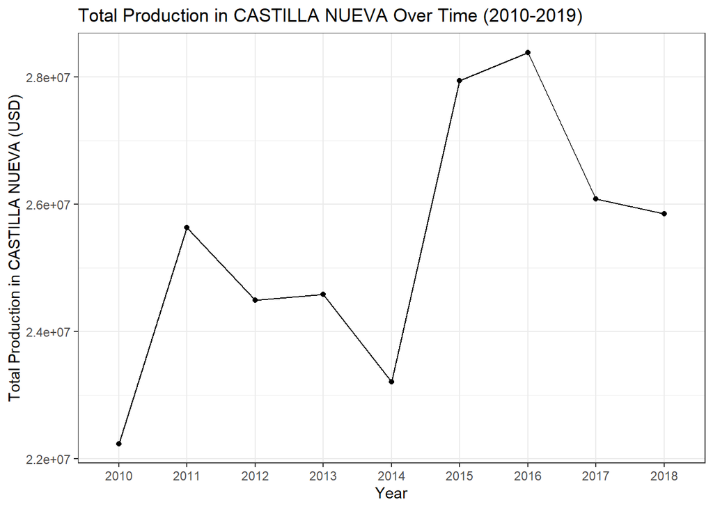

```r
# 9. PLOT FOR CASTILLA NUEVA MUNICIPALITY

total_production$Year <- factor(total_production$Year)

plot_CASTILLA_NUEVA <-  total_production %>%
  filter(Municipality == "CASTILLA NUEVA") %>%
  ggplot(aes(x = Year, y = total_production, group = 1)) +
  geom_point() +
  geom_line() +
  theme_bw() +
  labs(x = "Year",
       y = "Total Production in CASTILLA NUEVA (USD)",
       title = "Total Production in CASTILLA NUEVA Over Time (2010-2019)")

plot_CASTILLA_NUEVA
```

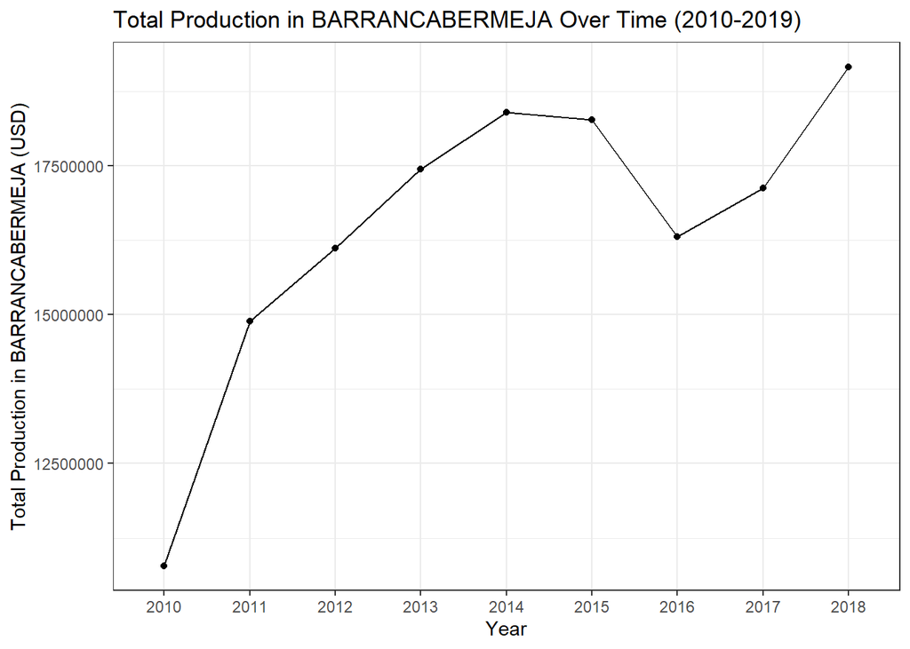

```r
# 10. PLOT FOR BARRANCABERMEJA MINICIPALITY

total_production$Year <- factor(total_production$Year)

plot_BARRANCABERMEJA <-  total_production %>%
  filter(Municipality == "BARRANCABERMEJA") %>%
  ggplot(aes(x = Year, y = total_production, group = 1)) +
  geom_point() +
  geom_line() +
  theme_bw() +
  labs(x = "Year",
       y = "Total Production in BARRANCABERMEJA (USD)",
       title = "Total Production in BARRANCABERMEJA Over Time (2010-2019)")

plot_BARRANCABERMEJA
```

**Notes and Observations About Individual Municipalities**

1. Municipalities with only one production year: MUNICIPIO NN PUTUMAYO, SAN JOSE DE FRAGUA, RIO NEGRO, FUENTE DE ORO, HATO COROZAL. We decided to deleted them.
2. Municipalities with two production years: SINCE, VILLANUEVE. We decided to keep them. Just keep in mind that we have those.
3. Looking at distribution of total production. It is right skewed. Here is a list of 10 fields (in descending order, whose production is higher than average production for a field at that municipality.)

Municipality Field mean_production 1 MANAURE CHUCHUPA 5442611. 2 MANAURE CHUCHUPA 2 3213472. 3 URIBIA CHUCHUPA 2575570. 4 PUERTO GAITAN RUBIALES 2412208. 5 RIOHACHA CHUCHUPA 2407954. 6 PUERTO GAITAN QUIFA 1305866. 7 URIBIA CHUCHUPA 2 1036275. 8 RIOHACHA CHUCHUPA 2 968835. 9 MUNICIPIO NN GIBRALTAR 628420. 10 DIBULLA CHUCHUPA 580434.